# Koodikirja, ESS 2023 - Suomen aineisto suomeksi

Arho Toikka

2026-01-06

Tämä on koodikirja Sosiaalitutkimuksen tilastolliset menetelmät -kurssille suomennetulle vuonna 2023 kerätylle kierroksen 11 aineistolle. Koodikirjassa kuvataan aineiston muuttujat, mutta muita koodikirjan elementtejä tässä dokumentissa ei ole. Esimerkiksi otanta-asetelmaa ei siis kuvata.

Aineisto on suomennettu ESS Data Portalin kautta jaettavasta englanninkielisestä aineistosta: European Social Survey European Research Infrastructure (ESS ERIC). (2025). ESS11 integrated file, edition 4.0 [Data set]. Sikt - Norwegian Agency for Shared Services in Education and Research. https://doi.org/10.21338/ess11e04_0 Aineisto on jaettu CC BY-NC-SA 4.0 -lisenssillä https://creativecommons.org/licenses/by-nc-sa/4.0/deed.fi, eli sitä saa jakaa ja muunnella ei-kaupallisiin tarkoituksiin.

Koko aineiston otoskoko on 1563. Yksittäisiin kysymyksiin vastanneiden määrä vaihtelee. Tässä dokumentissa käytetään merkintää NA (Not Applicable) kuvaamaan kaikkia tilanteita, jossa vastaajalta ei ole vastausta käytettävissä. Tämä voi tarkoittaa, että kysymystä ei ole kysytty (jos ei ole puolisia, ei kysytty hänen iästään), mitään vastausta ei ole jostain syystä saatu tai kirjattu, tai vastaaja on vastannut, että ei osaa sanoa, ei halua kertoa, tai vastaavaa. Nämä vaihtoehdot on siis tästä aineistotiedostosta poistettu ja itse aineistotiedostossa on näissä kaikissa tapauksissa tyhjä solu. Tilasto-ohjelmistot huomioivat tämän automaattisesti ja jättävät tällaiset vastaajat pois analyyseista.

## **aineisto**: Aineiston nimi

Vakio.

## **esskierros**: ESS-aineistokeruun kierros

Vakio.

Arvo kaikilla vastaajilla: `11`

## **idno**: Vastaajan tunnistenumero

| Tieto | Arvo |
| --- | --- |
| Vastanneita | 1563.00 |
| Keskiarvo | 68936.15 |
| Keskihajonta | 10398.52 |
| Minimi | 50003.00 |
| Maksimi | 86446.00 |

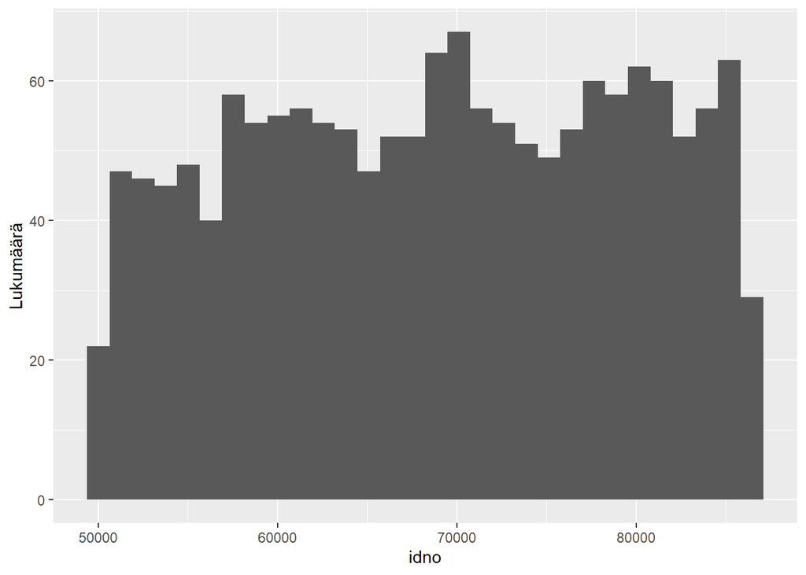

## **asetelmapaino**: Asetelmapaino

Vakio.

Arvo kaikilla vastaajilla: `1`

## **analyysipaino_suomi**: Analyysipaino Suomen väestöön painottaen

[output not shown]

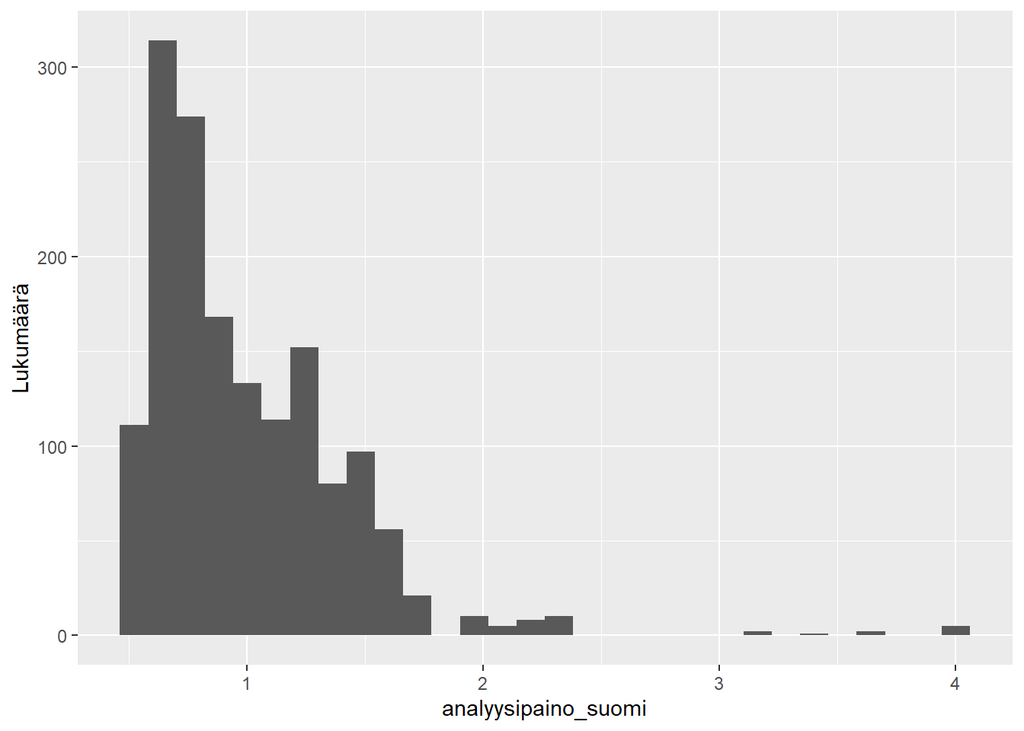

## **Sukupuoli**: Vastaajan sukupuoli

| Luokka | n | % | % vastanneista |
| --- | --- | --- | --- |
| Mies | 770 | 49.3% | 49.3% |
| Nainen | 793 | 50.7% | 50.7% |

## **Syntymävuosi**: Vastaajan syntymävuosi

| Tieto | Arvo |
| --- | --- |
| Vastanneita | 1563.00 |
| Keskiarvo | 1970.17 |
| Keskihajonta | 19.31 |
| Minimi | 1934.00 |
| Maksimi | 2008.00 |

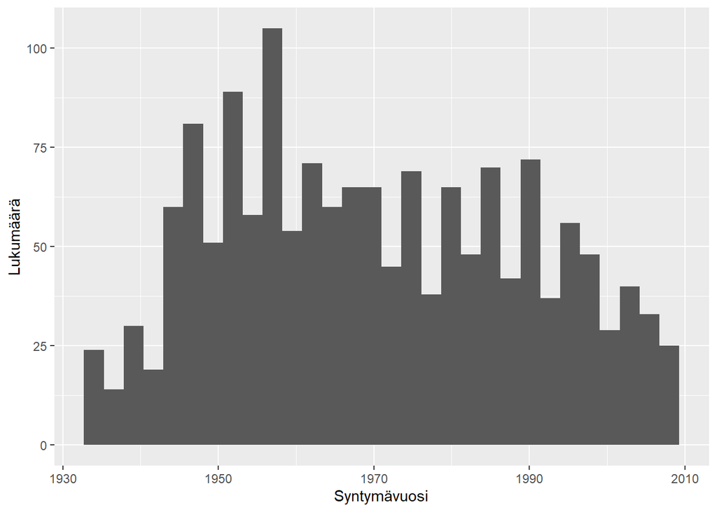

## **Ammatti_pääluokka**: Vastaajan ammatti, Ammattiluokitus 2010, pääluokka

| Luokka | n | % | % vastanneista |
| --- | --- | --- | --- |
| Sotilaat | 1 | 0.1% | 0.1% |
| Johtajat | 80 | 5.1% | 5.2% |
| Erityisasiantuntijat | 446 | 28.5% | 29.0% |
| Asiantuntijat | 270 | 17.3% | 17.6% |
| Toimisto- ja asiakaspalvelutyöntekijät | 106 | 6.8% | 6.9% |
| Palvelu- ja myyntityöntekijät | 253 | 16.2% | 16.5% |
| Maanviljelijät, metsätyöntekijät ym. | 53 | 3.4% | 3.4% |
| Rakennus-, korjaus- ja valmistustyöntekijät | 132 | 8.4% | 8.6% |
| Prosessi- ja kuljetustyöntekijät | 94 | 6.0% | 6.1% |
| Muut työntekijät | 102 | 6.5% | 6.6% |
| NA | 26 | 1.7% | - |

## **Ammatti_alaluokka**: Vastaajan ammatti, Ammattiluokitus 2010, 2-numerotason luokka

| Luokka | n | % | % vastanneista |
| --- | --- | --- | --- |
| Aliupseerit | 1 | 0.1% | 0.1% |
| Johtajat, ylimmät virkamiehet ja järjestöjen johtajat | 7 | 0.4% | 0.5% |
| Hallintojohtajat ja kaupalliset johtajat | 27 | 1.7% | 1.8% |
| Tuotantotoiminnan ja yhteiskunnan peruspalvelujen johtajat | 40 | 2.6% | 2.6% |
| Hotelli- ja ravintola-alan, vähittäiskaupan ja muiden palvelualojen johtajat | 6 | 0.4% | 0.4% |
| Luonnontieteiden ja tekniikan erityisasiantuntijat | 101 | 6.5% | 6.6% |
| Terveydenhuollon erityisasiantuntijat | 31 | 2.0% | 2.0% |
| Opettajat ja muut opetusalan erityisasiantuntijat | 110 | 7.0% | 7.2% |
| Liike-elämän ja hallinnon erityisasiantuntijat | 91 | 5.8% | 5.9% |
| Tieto- ja viestintäteknologian erityisasiantuntijat | 51 | 3.3% | 3.3% |
| Lainopilliset, sosiaalialan ja kulttuurialan erityisasiantuntijat | 62 | 4.0% | 4.0% |
| Luonnontieteiden ja tekniikan asiantuntijat | 43 | 2.8% | 2.8% |
| Terveydenhuollon asiantuntijat | 69 | 4.4% | 4.5% |
| Liike-elämän ja hallinnon asiantuntijat | 91 | 5.8% | 5.9% |
| Lainopilliset avustajat sekä sosiaali- ja kulttuurialan asiantuntijat | 55 | 3.5% | 3.6% |
| Informaatio- ja tietoliikenneteknologian asiantuntijat | 12 | 0.8% | 0.8% |
| Toimistotyöntekijät | 29 | 1.9% | 1.9% |
| Asiakaspalvelutyöntekijät | 32 | 2.0% | 2.1% |
| Laskennan ja varastoinnin toimistotyöntekijät | 22 | 1.4% | 1.4% |
| Muut toimisto- ja asiakaspalvelutyöntekijät | 23 | 1.5% | 1.5% |
| Palvelutyöntekijät | 74 | 4.7% | 4.8% |
| Myyjät, kauppiaat ym. | 75 | 4.8% | 4.9% |
| Hoivapalvelun ja terveydenhuollon työntekijät | 92 | 5.9% | 6.0% |
| Suojelu- ja vartiointityöntekijät | 12 | 0.8% | 0.8% |
| Maanviljelijät ja eläintenkasvattajat ym. | 44 | 2.8% | 2.9% |
| Metsä- ja kalatalouden työntekijät | 9 | 0.6% | 0.6% |
| Rakennustyöntekijät ym. (pl. sähköasentajat) | 52 | 3.3% | 3.4% |
| Konepaja- ja valimotyöntekijät sekä asentajat ja korjaajat | 48 | 3.1% | 3.1% |
| Käsityötuotteiden valmistajat, hienomekaanikot sekä painoalan työntekijät | 4 | 0.3% | 0.3% |
| Sähkö- ja elektroniikka-alan työntekijät | 15 | 1.0% | 1.0% |
| Elintarvike-, puutyö- ja vaatetus- ja jalkinealan valmistustyöntekijät ym. | 13 | 0.8% | 0.8% |
| Prosessityöntekijät | 44 | 2.8% | 2.9% |
| Teollisuustuotteiden kokoonpanijat | 11 | 0.7% | 0.7% |
| Kuljetustyöntekijät | 39 | 2.5% | 2.5% |
| Siivoojat, kotiapulaiset ja muut puhdistustyöntekijät | 45 | 2.9% | 2.9% |
| Maa-, metsä- ja kalatalouden avustavat työntekijät | 9 | 0.6% | 0.6% |
| Teollisuuden ja rakentamisen avustavat työntekijät | 25 | 1.6% | 1.6% |
| Avustavat keittiö- ja ruokatyöntekijät | 12 | 0.8% | 0.8% |
| Katumyyjät, kengänkiillottajat ym. | 1 | 0.1% | 0.1% |
| Katujen puhtaanapidon ja jätehuollon työntekijät ym. | 10 | 0.6% | 0.7% |
| NA | 26 | 1.7% | - |

## **Maakunta**: Maakunta

| Luokka | n | % | % vastanneista |
| --- | --- | --- | --- |
| Keski-Suomi | 77 | 4.9% | 4.9% |
| Etelä-Pohjanmaa | 46 | 2.9% | 2.9% |
| Pohjanmaa | 49 | 3.1% | 3.1% |
| Satakunta | 69 | 4.4% | 4.4% |
| Pirkanmaa | 179 | 11.5% | 11.5% |
| Helsinki-Uusimaa | 456 | 29.2% | 29.2% |
| Varsinais-Suomi | 141 | 9.0% | 9.0% |
| Kanta-Häme | 36 | 2.3% | 2.3% |
| Päijät-Häme | 66 | 4.2% | 4.2% |
| Kymenlaakso | 66 | 4.2% | 4.2% |
| Etelä-Karjala | 28 | 1.8% | 1.8% |
| Etelä-Savo | 40 | 2.6% | 2.6% |
| Pohjois-Savo | 78 | 5.0% | 5.0% |
| Pohjois-Karjala | 52 | 3.3% | 3.3% |
| Kainuu | 25 | 1.6% | 1.6% |
| Keski-Pohjanmaa | 13 | 0.8% | 0.8% |
| Pohjois-Pohjanmaa | 86 | 5.5% | 5.5% |
| Lappi | 48 | 3.1% | 3.1% |
| Åland | 8 | 0.5% | 0.5% |

# A: Media ja sosiaalinen luottamus

## **A1_min**: Kuinka paljon aikaa käytät politiikkaa ja ajankohtaisia asioita käsittelevien uutisten katseluun, kuunteluun tai lukemiseen tavallisena arkipäivänä?

| Tieto | Arvo |
| --- | --- |
| Vastanneita | 1559.00 |
| Keskiarvo | 70.09 |
| Keskihajonta | 61.76 |
| Minimi | 0.00 |
| Maksimi | 780.00 |

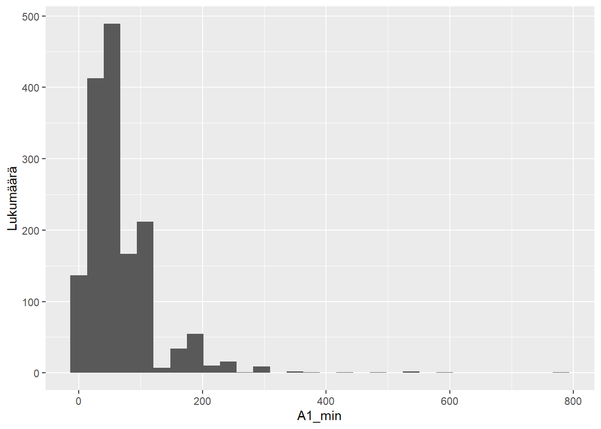

## **A2**: Kuinka usein käytät internetiä tietokoneella, tabletilla, älypuhelimella tai muulla laitteella joko työhösi tai omiin asioihisi?

| Luokka | n | % | % vastanneista |
| --- | --- | --- | --- |
| En koskaan | 95 | 6.1% | 6.1% |
| Melko harvoin | 37 | 2.4% | 2.4% |
| Muutaman kerran viikossa | 53 | 3.4% | 3.4% |
| Useimpina päivinä | 40 | 2.6% | 2.6% |
| Päivittäin | 1338 | 85.6% | 85.6% |

## **A3_min**: Kuinka paljon kulutat aikaa tavallisena arkipäivänä internetin käyttöön tietokoneella, tabletilla, älypuhelimella tai muulla laitteella joko työhösi tai omiin asioihisi?

| Tieto | Arvo |
| --- | --- |
| Vastanneita | 1372.00 |
| Keskiarvo | 244.38 |
| Keskihajonta | 184.91 |
| Minimi | 5.00 |
| Maksimi | 960.00 |

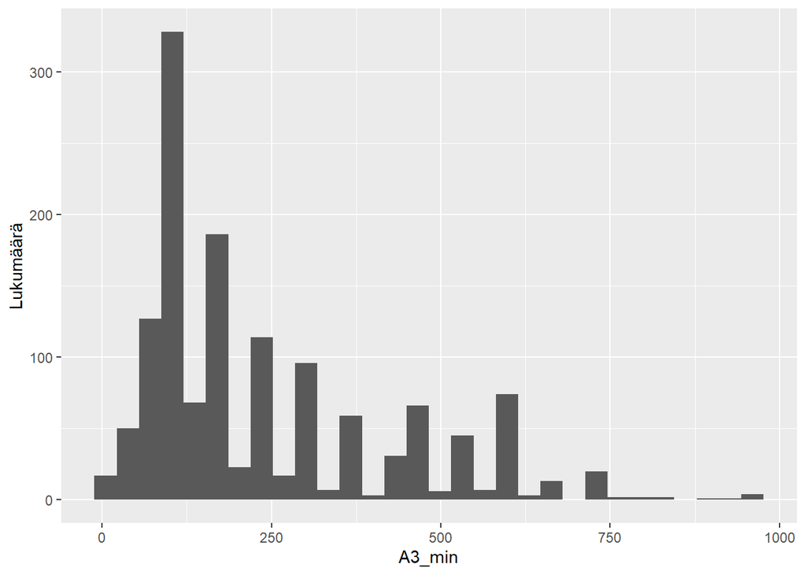

## **A4**: Voiko mielestäsi ihmisiin luottaa, vai onko niin, ettei ihmisten suhteen voi olla liian varovainen?

| Luokka | n | % | % vastanneista |
| --- | --- | --- | --- |
| Ei voi olla liian varovainen | 9 | 0.6% | 0.6% |
| 1 | 10 | 0.6% | 0.6% |
| 2 | 24 | 1.5% | 1.5% |
| 3 | 51 | 3.3% | 3.3% |
| 4 | 65 | 4.2% | 4.2% |
| 5 | 158 | 10.1% | 10.1% |
| 6 | 149 | 9.5% | 9.5% |
| 7 | 374 | 23.9% | 24.0% |
| 8 | 523 | 33.5% | 33.5% |
| 9 | 156 | 10.0% | 10.0% |
| Useimpiin ihmisiin voi luottaa | 42 | 2.7% | 2.7% |
| NA | 2 | 0.1% | - |

## **A5**: Oletko sitä mieltä, että useimmat ihmiset tilaisuuden tullen yrittäisivät käyttää sinua hyväkseen vai luuletko, että ihmiset yrittäisivät olla reiluja?

| Luokka | n | % | % vastanneista |
| --- | --- | --- | --- |
| Useimmat ihmiset yrittäisivät käyttää minua hyväkseen | 5 | 0.3% | 0.3% |
| 1 | 3 | 0.2% | 0.2% |
| 2 | 27 | 1.7% | 1.7% |
| 3 | 36 | 2.3% | 2.3% |
| 4 | 58 | 3.7% | 3.7% |
| 5 | 148 | 9.5% | 9.5% |
| 6 | 147 | 9.4% | 9.4% |
| 7 | 355 | 22.7% | 22.7% |
| 8 | 504 | 32.2% | 32.3% |
| 9 | 219 | 14.0% | 14.0% |
| Useimmat ihmiset yrittäisivät olla reiluja | 59 | 3.8% | 3.8% |
| NA | 2 | 0.1% | - |

## **A6**: Ajatteletko, että useimmat ihmiset pyrkivät olemaan auttavaisia toisia kohtaan vai että he ajattelevat vain omaa etuaan?

| Luokka | n | % | % vastanneista |
| --- | --- | --- | --- |
| Ihmiset ajattelevat enimmäkseen omaa etuaan | 9 | 0.6% | 0.6% |
| 1 | 3 | 0.2% | 0.2% |
| 2 | 41 | 2.6% | 2.6% |
| 3 | 75 | 4.8% | 4.8% |
| 4 | 122 | 7.8% | 7.8% |
| 5 | 244 | 15.6% | 15.6% |
| 6 | 209 | 13.4% | 13.4% |
| 7 | 372 | 23.8% | 23.8% |
| 8 | 343 | 21.9% | 22.0% |
| 9 | 111 | 7.1% | 7.1% |
| Ihmiset yrittävät enimmäkseen olla auttavaisia | 33 | 2.1% | 2.1% |
| NA | 1 | 0.1% | - |

# B: Politiikka

## **B1**: Kuinka kiinnostunut olet politiikasta?

| Luokka | n | % | % vastanneista |
| --- | --- | --- | --- |
| Erittäin kiinnostunut | 256 | 16.4% | 16.4% |
| Melko kiinnostunut | 822 | 52.6% | 52.6% |
| Et kovin kiinnostunut | 398 | 25.5% | 25.5% |
| Et lainkaan kiinnostunut | 86 | 5.5% | 5.5% |
| NA | 1 | 0.1% | - |

## **B2**: Kuinka paljon mielestäsi suomalaisessa poliittisessa järjestelmässä sinun kaltaisesi ihmiset pystyvät vaikuttamaan siihen, mitä hallitus tekee?

| Luokka | n | % | % vastanneista |
| --- | --- | --- | --- |
| Ei lainkaan | 152 | 9.7% | 9.8% |
| Erittäin vähän | 664 | 42.5% | 42.7% |
| Jonkin verran | 624 | 39.9% | 40.2% |
| Paljon | 95 | 6.1% | 6.1% |
| Erittäin paljon | 19 | 1.2% | 1.2% |
| NA | 9 | 0.6% | - |

## **B3**: Pystyisitkö mielestäsi toimimaan aktiivisesti ryhmässä, joka on tekemisissä poliittisten kysymysten kanssa?

| Luokka | n | % | % vastanneista |
| --- | --- | --- | --- |
| En pystyisi lainkaan | 259 | 16.6% | 16.6% |
| Pystyisin jossain määrin | 702 | 44.9% | 45.0% |
| Pystyisin melko paljon | 309 | 19.8% | 19.8% |
| Pystyisin hyvin paljon | 213 | 13.6% | 13.7% |
| Pystyisin täydellisesti | 77 | 4.9% | 4.9% |
| NA | 3 | 0.2% | - |

## **B4**: Onko mielestäsi Suomen poliittisessa järjestelmässä kaltaisillasi ihmisillä mahdollisuuksia vaikuttaa politiikkaan?

| Luokka | n | % | % vastanneista |
| --- | --- | --- | --- |
| Ei lainkaan | 96 | 6.1% | 6.2% |
| Erittäin vähän | 491 | 31.4% | 31.6% |
| Jonkin verran | 775 | 49.6% | 49.8% |
| Paljon | 169 | 10.8% | 10.9% |
| Erittäin paljon | 24 | 1.5% | 1.5% |
| NA | 8 | 0.5% | - |

## **B5**: Kuinka paljon luotat omiin kykyihisi osallistua politiikkaan?

| Luokka | n | % | % vastanneista |
| --- | --- | --- | --- |
| En luota lainkaan | 293 | 18.7% | 18.8% |
| Luotan jossain määrin | 678 | 43.4% | 43.5% |
| Luotan melko paljon | 381 | 24.4% | 24.4% |
| Luotan hyvin paljon | 174 | 11.1% | 11.2% |
| Luotan täydellisesti | 33 | 2.1% | 2.1% |
| NA | 4 | 0.3% | - |

## **B6**: Kuinka paljon henkilökohtaisesti luotat eduskuntaan?

| Luokka | n | % | % vastanneista |
| --- | --- | --- | --- |
| En luota ollenkaan | 26 | 1.7% | 1.7% |
| 1 | 19 | 1.2% | 1.2% |
| 2 | 38 | 2.4% | 2.4% |
| 3 | 81 | 5.2% | 5.2% |
| 4 | 98 | 6.3% | 6.3% |
| 5 | 152 | 9.7% | 9.7% |
| 6 | 224 | 14.3% | 14.4% |
| 7 | 345 | 22.1% | 22.1% |
| 8 | 368 | 23.5% | 23.6% |
| 9 | 171 | 10.9% | 11.0% |
| Luotan täysin | 37 | 2.4% | 2.4% |
| NA | 4 | 0.3% | - |

## **B7**: Kuinka paljon henkilökohtaisesti luotat oikeusjärjestelmään?

| Luokka | n | % | % vastanneista |
| --- | --- | --- | --- |
| En luota ollenkaan | 7 | 0.4% | 0.4% |
| 1 | 7 | 0.4% | 0.4% |
| 2 | 30 | 1.9% | 1.9% |
| 3 | 42 | 2.7% | 2.7% |
| 4 | 58 | 3.7% | 3.7% |
| 5 | 95 | 6.1% | 6.1% |
| 6 | 122 | 7.8% | 7.8% |
| 7 | 255 | 16.3% | 16.4% |
| 8 | 429 | 27.4% | 27.6% |
| 9 | 409 | 26.2% | 26.3% |
| Luotan täysin | 102 | 6.5% | 6.6% |
| NA | 7 | 0.4% | - |

## **B8**: Kuinka paljon henkilökohtaisesti luotat poliisiin?

| Luokka | n | % | % vastanneista |
| --- | --- | --- | --- |
| En luota ollenkaan | 4 | 0.3% | 0.3% |
| 1 | 5 | 0.3% | 0.3% |
| 2 | 10 | 0.6% | 0.6% |
| 3 | 14 | 0.9% | 0.9% |
| 4 | 27 | 1.7% | 1.7% |
| 5 | 35 | 2.2% | 2.2% |
| 6 | 66 | 4.2% | 4.2% |
| 7 | 155 | 9.9% | 9.9% |
| 8 | 385 | 24.6% | 24.6% |
| 9 | 611 | 39.1% | 39.1% |
| Luotan täysin | 250 | 16.0% | 16.0% |
| NA | 1 | 0.1% | - |

## **B9**: Kuinka paljon henkilökohtaisesti luotat poliitikkoihin?

| Luokka | n | % | % vastanneista |
| --- | --- | --- | --- |
| En luota ollenkaan | 44 | 2.8% | 2.8% |
| 1 | 38 | 2.4% | 2.4% |
| 2 | 88 | 5.6% | 5.6% |
| 3 | 126 | 8.1% | 8.1% |
| 4 | 171 | 10.9% | 11.0% |
| 5 | 264 | 16.9% | 16.9% |
| 6 | 311 | 19.9% | 19.9% |
| 7 | 348 | 22.3% | 22.3% |
| 8 | 145 | 9.3% | 9.3% |
| 9 | 23 | 1.5% | 1.5% |
| Luotan täysin | 2 | 0.1% | 0.1% |
| NA | 3 | 0.2% | - |

## **B10**: Kuinka paljon henkilökohtaisesti luotat poliittisiin puolueisiin?

| Luokka | n | % | % vastanneista |
| --- | --- | --- | --- |
| En luota ollenkaan | 38 | 2.4% | 2.4% |
| 1 | 37 | 2.4% | 2.4% |
| 2 | 70 | 4.5% | 4.5% |
| 3 | 127 | 8.1% | 8.2% |
| 4 | 165 | 10.6% | 10.6% |
| 5 | 297 | 19.0% | 19.1% |
| 6 | 305 | 19.5% | 19.7% |
| 7 | 324 | 20.7% | 20.9% |
| 8 | 163 | 10.4% | 10.5% |
| 9 | 24 | 1.5% | 1.5% |
| Luotan täysin | 2 | 0.1% | 0.1% |
| NA | 11 | 0.7% | - |

## **B11**: Kuinka paljon henkilökohtaisesti luotat Euroopan parlamenttiin?

| Luokka | n | % | % vastanneista |
| --- | --- | --- | --- |
| En luota ollenkaan | 39 | 2.5% | 2.6% |
| 1 | 35 | 2.2% | 2.3% |
| 2 | 55 | 3.5% | 3.6% |
| 3 | 91 | 5.8% | 6.0% |
| 4 | 124 | 7.9% | 8.1% |
| 5 | 270 | 17.3% | 17.7% |
| 6 | 247 | 15.8% | 16.2% |
| 7 | 349 | 22.3% | 22.9% |
| 8 | 233 | 14.9% | 15.3% |
| 9 | 67 | 4.3% | 4.4% |
| Luotan täysin | 12 | 0.8% | 0.8% |
| NA | 41 | 2.6% | - |

## **B12**: Kuinka paljon henkilökohtaisesti luotat YK eli Yhdistyneisiin kansakuntiin?

| Luokka | n | % | % vastanneista |
| --- | --- | --- | --- |
| En luota ollenkaan | 29 | 1.9% | 1.9% |
| 1 | 29 | 1.9% | 1.9% |
| 2 | 41 | 2.6% | 2.7% |
| 3 | 55 | 3.5% | 3.6% |
| 4 | 94 | 6.0% | 6.2% |
| 5 | 213 | 13.6% | 14.0% |
| 6 | 193 | 12.3% | 12.7% |
| 7 | 327 | 20.9% | 21.5% |
| 8 | 343 | 21.9% | 22.6% |
| 9 | 161 | 10.3% | 10.6% |
| Luotan täysin | 35 | 2.2% | 2.3% |
| NA | 43 | 2.8% | - |

## **B13**: Äänestitkö viime eduskuntavaaleissa huhtikuussa 2023?

| Luokka | n | % | % vastanneista |
| --- | --- | --- | --- |
| Kyllä | 1295 | 82.9% | 83.7% |
| Ei | 200 | 12.8% | 12.9% |
| Ei äänioikeutettu | 52 | 3.3% | 3.4% |
| NA | 16 | 1.0% | - |

## **B14**: Mitä puoluetta äänestit?

| Luokka | n | % | % vastanneista |
| --- | --- | --- | --- |
| Suomen Sosialidemokraattinen Puolue | 293 | 18.7% | 24.9% |
| Suomen Keskusta | 106 | 6.8% | 9.0% |
| Kansallinen Kokoomus | 257 | 16.4% | 21.8% |
| Suomen ruotsalainen kansanpuolue | 58 | 3.7% | 4.9% |
| Suomen Kristillisdemokraatit | 56 | 3.6% | 4.8% |
| Vihreä liitto | 117 | 7.5% | 9.9% |
| Vasemmistoliitto | 73 | 4.7% | 6.2% |
| Perussuomalaiset | 176 | 11.3% | 15.0% |
| Liberaalipuolue | 11 | 0.7% | 0.9% |
| Piraattipuolue | 2 | 0.1% | 0.2% |
| Eläinoikeuspuolue | 1 | 0.1% | 0.1% |
| Liike Nyt | 14 | 0.9% | 1.2% |
| Valta kuuluu kansalle | 1 | 0.1% | 0.1% |
| Vapauden liitto | 7 | 0.4% | 0.6% |
| För Åland | 1 | 0.1% | 0.1% |
| Jokin muu | 4 | 0.3% | 0.3% |
| NA | 386 | 24.7% | - |

## **B15**: Oletko ottanut yhteyttä poliitikkoon tai valtion tai kunnan virkamieheen viimeisten 12 kuukauden aikana?

| Luokka | n | % | % vastanneista |
| --- | --- | --- | --- |
| Kyllä | 374 | 23.9% | 24.0% |
| En | 1186 | 75.9% | 76.0% |
| NA | 3 | 0.2% | - |

## **B16**: Oletko tukenut taloudellisesti tai osallistunut jonkin puolueen tai poliittisen ryhmän toimintaan viimeisten 12 kuukauden aikana?

| Luokka | n | % | % vastanneista |
| --- | --- | --- | --- |
| Kyllä | 97 | 6.2% | 6.2% |
| En | 1466 | 93.8% | 93.8% |

## **B17**: Oletko käyttänyt tai pitänyt esillä kampanjatuotteita kuten rintamerkkejä, tarroja tms. viimeisten 12 kuukauden aikana?

| Luokka | n | % | % vastanneista |
| --- | --- | --- | --- |
| Kyllä | 148 | 9.5% | 9.5% |
| En | 1415 | 90.5% | 90.5% |

## **B18**: Oletko allekirjoittanut kansalaisadressin tai -vetoomuksen viimeisten 12 kuukauden aikana?

| Luokka | n | % | % vastanneista |
| --- | --- | --- | --- |
| Kyllä | 560 | 35.8% | 35.9% |
| En | 998 | 63.9% | 64.1% |
| NA | 5 | 0.3% | - |

## **B19**: Oletko osallistunut mielenosoitukseen viimeisten 12 kuukauden aikana?

| Luokka | n | % | % vastanneista |
| --- | --- | --- | --- |
| Kyllä | 79 | 5.1% | 5.1% |
| En | 1482 | 94.8% | 94.9% |
| NA | 2 | 0.1% | - |

## **B20**: Oletko boikotoinut, eli kieltäytynyt tai välttänyt ostamasta tiettyjä tuotteita viimeisten 12 kuukauden aikana?

| Luokka | n | % | % vastanneista |
| --- | --- | --- | --- |
| Kyllä | 841 | 53.8% | 54.1% |
| En | 713 | 45.6% | 45.9% |
| NA | 9 | 0.6% | - |

## **B21**: Oletko julkaissut tai jakanut netissä jotain politiikkaan liittyvää, esimerkiksi blogissa, sähköpostilla tai sosiaalisessa mediassa, kuten Facebookissa tai Twitterissä viimeisten 12 kuukauden aikana

| Luokka | n | % | % vastanneista |
| --- | --- | --- | --- |
| Kyllä | 284 | 18.2% | 18.2% |
| En | 1277 | 81.7% | 81.8% |
| NA | 2 | 0.1% | - |

## **B22**: Oletko osallistunut vapaaehtoistyöhön voittoa tavoittelemattomassa organisaatiossa tai hyväntekeväisyysjärjestössä viimeisten 12 kuukauden aikana?

| Luokka | n | % | % vastanneista |
| --- | --- | --- | --- |
| Kyllä | 486 | 31.1% | 31.1% |
| En | 1077 | 68.9% | 68.9% |

## **B23**: Tuntuuko jokin poliittinen puolue sinusta läheisemmältä kuin muut puolueet?

| Luokka | n | % | % vastanneista |
| --- | --- | --- | --- |
| Kyllä | 956 | 61.2% | 62.2% |
| Ei | 581 | 37.2% | 37.8% |
| NA | 26 | 1.7% | - |

## **B24**: Mikä puolue tuntuu sinusta läheisemmältä kuin muut puolueet?

| Luokka | n | % | % vastanneista |
| --- | --- | --- | --- |
| Suomen Sosialidemokraattinen Puolue | 216 | 13.8% | 24.0% |
| Suomen Keskusta | 79 | 5.1% | 8.8% |
| Kansallinen Kokoomus | 179 | 11.5% | 19.9% |
| Suomen ruotsalainen kansanpuolue | 46 | 2.9% | 5.1% |
| Suomen kristillisdemokraatit | 41 | 2.6% | 4.6% |
| Vihreä liitto | 113 | 7.2% | 12.5% |
| Vasemmistoliitto | 93 | 6.0% | 10.3% |
| Perussuomalaiset | 117 | 7.5% | 13.0% |
| Liberaalipuolue | 6 | 0.4% | 0.7% |
| Piraattipuolue | 1 | 0.1% | 0.1% |
| Eläinoikeuspuolue | 1 | 0.1% | 0.1% |
| Avoin Puolue | 1 | 0.1% | 0.1% |
| Suomen Kommunistinen Puolue | 1 | 0.1% | 0.1% |
| Vapauden liitto | 4 | 0.3% | 0.4% |
| För Åland | 1 | 0.1% | 0.1% |
| Jokin muu | 2 | 0.1% | 0.2% |
| NA | 662 | 42.4% | - |

## **B25**: Kuinka läheiseksi tunnet kyseisen puolueen?

| Luokka | n | % | % vastanneista |
| --- | --- | --- | --- |
| Erittäin läheiseksi | 71 | 4.5% | 7.9% |
| Melko läheiseksi | 671 | 42.9% | 74.8% |
| Et läheiseksi | 141 | 9.0% | 15.7% |
| Et lainkaan läheiseksi | 14 | 0.9% | 1.6% |
| NA | 666 | 42.6% | - |

## **B26**: Mihin kohtaan sijoittaisit itsesi vasemmisto-oikeisto-akselille?

| Luokka | n | % | % vastanneista |
| --- | --- | --- | --- |
| Vasemmisto | 34 | 2.2% | 2.2% |
| 1 | 32 | 2.0% | 2.1% |
| 2 | 80 | 5.1% | 5.3% |
| 3 | 139 | 8.9% | 9.2% |
| 4 | 154 | 9.9% | 10.2% |
| 5 | 349 | 22.3% | 23.0% |
| 6 | 156 | 10.0% | 10.3% |
| 7 | 235 | 15.0% | 15.5% |
| 8 | 210 | 13.4% | 13.9% |
| 9 | 78 | 5.0% | 5.1% |
| Oikeisto | 49 | 3.1% | 3.2% |
| NA | 47 | 3.0% | - |

## **B27**: Yleisesti ottaen, kuinka tyytyväinen olet elämääsi nykyisin?

| Luokka | n | % | % vastanneista |
| --- | --- | --- | --- |
| Äärimmäisen tyytymätön | 4 | 0.3% | 0.3% |
| 1 | 1 | 0.1% | 0.1% |
| 2 | 11 | 0.7% | 0.7% |
| 3 | 23 | 1.5% | 1.5% |
| 4 | 28 | 1.8% | 1.8% |
| 5 | 70 | 4.5% | 4.5% |
| 6 | 65 | 4.2% | 4.2% |
| 7 | 212 | 13.6% | 13.6% |
| 8 | 520 | 33.3% | 33.3% |
| 9 | 472 | 30.2% | 30.2% |
| Äärimmäisen tyytyväinen | 156 | 10.0% | 10.0% |
| NA | 1 | 0.1% | - |

## **B28**: Kuinka tyytyväinen kaiken kaikkiaan olet tämän hetkiseen taloudelliseen tilanteeseen Suomessa?

| Luokka | n | % | % vastanneista |
| --- | --- | --- | --- |
| Äärimmäisen tyytymätön | 20 | 1.3% | 1.3% |
| 1 | 26 | 1.7% | 1.7% |
| 2 | 67 | 4.3% | 4.3% |
| 3 | 141 | 9.0% | 9.1% |
| 4 | 194 | 12.4% | 12.5% |
| 5 | 216 | 13.8% | 13.9% |
| 6 | 329 | 21.0% | 21.2% |
| 7 | 339 | 21.7% | 21.8% |
| 8 | 167 | 10.7% | 10.8% |
| 9 | 39 | 2.5% | 2.5% |
| Äärimmäisen tyytyväinen | 14 | 0.9% | 0.9% |
| NA | 11 | 0.7% | - |

## **B29**: Kuinka tyytyväinen olet siihen, miten Suomen nykyinen hallitus hoitaa tehtävänsä?

| Luokka | n | % | % vastanneista |
| --- | --- | --- | --- |
| Äärimmäisen tyytymätön | 89 | 5.7% | 5.8% |
| 1 | 69 | 4.4% | 4.5% |
| 2 | 144 | 9.2% | 9.4% |
| 3 | 158 | 10.1% | 10.3% |
| 4 | 173 | 11.1% | 11.3% |
| 5 | 228 | 14.6% | 14.9% |
| 6 | 224 | 14.3% | 14.6% |
| 7 | 242 | 15.5% | 15.8% |
| 8 | 159 | 10.2% | 10.4% |
| 9 | 36 | 2.3% | 2.4% |
| Äärimmäisen tyytyväinen | 9 | 0.6% | 0.6% |
| NA | 32 | 2.0% | - |

## **B30**: Kuinka tyytyväinen olet siihen, kuinka demokratia toimii Suomessa?

| Luokka | n | % | % vastanneista |
| --- | --- | --- | --- |
| Äärimmäisen tyytymätön | 10 | 0.6% | 0.7% |
| 1 | 20 | 1.3% | 1.3% |
| 2 | 31 | 2.0% | 2.0% |
| 3 | 64 | 4.1% | 4.2% |
| 4 | 78 | 5.0% | 5.1% |
| 5 | 155 | 9.9% | 10.1% |
| 6 | 190 | 12.2% | 12.4% |
| 7 | 307 | 19.6% | 20.0% |
| 8 | 411 | 26.3% | 26.7% |
| 9 | 229 | 14.7% | 14.9% |
| Äärimmäisen tyytyväinen | 42 | 2.7% | 2.7% |
| NA | 26 | 1.7% | - |

## **B31**: Mitä mieltä olet Suomen nykyisestä koulutusjärjestelmästä?

| Luokka | n | % | % vastanneista |
| --- | --- | --- | --- |
| Äärimmäisen huono | 6 | 0.4% | 0.4% |
| 1 | 8 | 0.5% | 0.5% |
| 2 | 24 | 1.5% | 1.5% |
| 3 | 38 | 2.4% | 2.5% |
| 4 | 50 | 3.2% | 3.2% |
| 5 | 82 | 5.2% | 5.3% |
| 6 | 148 | 9.5% | 9.5% |
| 7 | 370 | 23.7% | 23.9% |
| 8 | 494 | 31.6% | 31.9% |
| 9 | 272 | 17.4% | 17.5% |
| Äärimmäisen hyvä | 59 | 3.8% | 3.8% |
| NA | 12 | 0.8% | - |

## **B32**: Mitä mieltä olet Suomen terveyspalvelujen tasosta nykyisin?

| Luokka | n | % | % vastanneista |
| --- | --- | --- | --- |
| Äärimmäisen huono | 13 | 0.8% | 0.8% |
| 1 | 16 | 1.0% | 1.0% |
| 2 | 51 | 3.3% | 3.3% |
| 3 | 88 | 5.6% | 5.6% |
| 4 | 120 | 7.7% | 7.7% |
| 5 | 165 | 10.6% | 10.6% |
| 6 | 221 | 14.1% | 14.2% |
| 7 | 384 | 24.6% | 24.6% |
| 8 | 324 | 20.7% | 20.8% |
| 9 | 143 | 9.1% | 9.2% |
| Äärimmäisen hyvä | 35 | 2.2% | 2.2% |
| NA | 3 | 0.2% | - |

## **B33**: Missä määrin olet samaa tai eri mieltä: Valtiovallan pitäisi ryhtyä toimenpiteisiin tuloerojen vähentämiseksi.

| Luokka | n | % | % vastanneista |
| --- | --- | --- | --- |
| Täysin samaa mieltä | 344 | 22.0% | 22.2% |
| Samaa mieltä | 618 | 39.5% | 39.9% |
| En samaa enkä eri mieltä | 358 | 22.9% | 23.1% |
| Eri mieltä | 196 | 12.5% | 12.7% |
| Täysin eri mieltä | 32 | 2.0% | 2.1% |
| NA | 15 | 1.0% | - |

## **B34**: Missä määrin olet samaa tai eri mieltä: Homoilla ja lesboilla pitäisi olla vapaus elää elämäänsä haluamallaan tavalla.

| Luokka | n | % | % vastanneista |
| --- | --- | --- | --- |
| Täysin samaa mieltä | 825 | 52.8% | 53.2% |
| Samaa mieltä | 516 | 33.0% | 33.3% |
| En samaa enkä eri mieltä | 140 | 9.0% | 9.0% |
| Eri mieltä | 45 | 2.9% | 2.9% |
| Täysin eri mieltä | 25 | 1.6% | 1.6% |
| NA | 12 | 0.8% | - |

## **B35**: Missä määrin olet samaa tai eri mieltä: Jos joku lähisukulaiseni olisi homo tai lesbo, häpeäisin sitä.

| Luokka | n | % | % vastanneista |
| --- | --- | --- | --- |
| Täysin samaa mieltä | 30 | 1.9% | 1.9% |
| Samaa mieltä | 46 | 2.9% | 3.0% |
| En samaa enkä eri mieltä | 117 | 7.5% | 7.6% |
| Eri mieltä | 403 | 25.8% | 26.0% |
| Täysin eri mieltä | 953 | 61.0% | 61.5% |
| NA | 14 | 0.9% | - |

## **B36**: Missä määrin olet samaa tai eri mieltä: Homo- ja lesbopareilla tulisi olla samanlainen adoptiooikeus kuin heteropareilla.

| Luokka | n | % | % vastanneista |
| --- | --- | --- | --- |
| Täysin samaa mieltä | 560 | 35.8% | 36.5% |
| Samaa mieltä | 470 | 30.1% | 30.6% |
| En samaa enkä eri mieltä | 216 | 13.8% | 14.1% |
| Eri mieltä | 194 | 12.4% | 12.6% |
| Täysin eri mieltä | 94 | 6.0% | 6.1% |
| NA | 29 | 1.9% | - |

## **B37**: Missä määrin olet samaa tai eri mieltä: Euroopan yhdentymistä pitäisi viedä pidemmälle vai se on mennyt jo liian pitkälle.

| Luokka | n | % | % vastanneista |
| --- | --- | --- | --- |
| Yhdentyminen on mennyt jo liian pitkälle | 41 | 2.6% | 2.7% |
| 1 | 27 | 1.7% | 1.8% |
| 2 | 78 | 5.0% | 5.1% |
| 3 | 106 | 6.8% | 6.9% |
| 4 | 136 | 8.7% | 8.9% |
| 5 | 388 | 24.8% | 25.4% |
| 6 | 229 | 14.7% | 15.0% |
| 7 | 247 | 15.8% | 16.2% |
| 8 | 190 | 12.2% | 12.5% |
| 9 | 51 | 3.3% | 3.3% |
| Yhdentymistä pitäisi viedä pidemmälle | 33 | 2.1% | 2.2% |
| NA | 37 | 2.4% | - |

## **B38**: Missä määrin olet samaa tai eri mieltä: Tottelevaisuus ja auktoriteettien kunnioittaminen ovat tärkeimmät arvot, jotka lasten tulisi oppia.

| Luokka | n | % | % vastanneista |
| --- | --- | --- | --- |
| Täysin samaa mieltä | 314 | 20.1% | 20.1% |
| Samaa mieltä | 572 | 36.6% | 36.7% |
| En samaa enkä eri mieltä | 291 | 18.6% | 18.7% |
| Eri mieltä | 318 | 20.3% | 20.4% |
| Täysin eri mieltä | 64 | 4.1% | 4.1% |
| NA | 4 | 0.3% | - |

## **B39**: Missä määrin olet samaa tai eri mieltä: Eniten Suomi tarvitsee uskollisuutta päättäjiä kohtaan.

| Luokka | n | % | % vastanneista |
| --- | --- | --- | --- |
| Täysin samaa mieltä | 64 | 4.1% | 4.2% |
| Samaa mieltä | 359 | 23.0% | 23.3% |
| En samaa enkä eri mieltä | 499 | 31.9% | 32.4% |
| Eri mieltä | 509 | 32.6% | 33.1% |
| Täysin eri mieltä | 107 | 6.8% | 7.0% |
| NA | 25 | 1.6% | - |

## **B40**: Kuinka paljon Suomen tulisi sallia sellaisten ihmisten muuttaa maahan asumaan, jotka kuuluvat samaan etniseen ryhmään kuin useimmat suomalaiset?

| Luokka | n | % | % vastanneista |
| --- | --- | --- | --- |
| Pitäisi sallia paljon | 410 | 26.2% | 26.6% |
| Pitäisi sallia melko paljo | 842 | 53.9% | 54.7% |
| Pitäisi sallia vähän | 277 | 17.7% | 18.0% |
| Ei pitäisi sallia lainkaan | 10 | 0.6% | 0.6% |
| NA | 24 | 1.5% | - |

## **B41**: Kuinka paljon Suomen tulisi sallia sellaisten ihmisten muuttaa maahan asumaan, jotka edustavat eri etnistä alkuperää kuin useimmat suomalaiset?

| Luokka | n | % | % vastanneista |
| --- | --- | --- | --- |
| Pitäisi sallia paljon | 250 | 16.0% | 16.2% |
| Pitäisi sallia melko paljon | 644 | 41.2% | 41.8% |
| Pitäisi sallia vähän | 572 | 36.6% | 37.1% |
| Ei pitäisi sallia lainkaan | 74 | 4.7% | 4.8% |
| NA | 23 | 1.5% | - |

## **B42**: Kuinka paljon Suomen tulisi sallia köyhemmistä Euroopan ulkopuolisista maista olevien ihmisten muuttaa Suomeen asumaan?

| Luokka | n | % | % vastanneista |
| --- | --- | --- | --- |
| Pitäisi sallia paljon | 203 | 13.0% | 13.3% |
| Pitäisi sallia melko paljon | 578 | 37.0% | 37.7% |
| Pitäisi sallia vähän | 652 | 41.7% | 42.6% |
| Ei pitäisi sallia lainkaan | 99 | 6.3% | 6.5% |
| NA | 31 | 2.0% | - |

## **B43**: Onko mielestäsi haitaksi vai eduksi Suomen taloudelle, että muista maista muuttaa ihmisiä Suomeen?

| Luokka | n | % | % vastanneista |
| --- | --- | --- | --- |
| Haitaksi taloudelle | 15 | 1.0% | 1.0% |
| 1 | 17 | 1.1% | 1.1% |
| 2 | 43 | 2.8% | 2.8% |
| 3 | 83 | 5.3% | 5.4% |
| 4 | 101 | 6.5% | 6.5% |
| 5 | 235 | 15.0% | 15.2% |
| 6 | 180 | 11.5% | 11.6% |
| 7 | 304 | 19.4% | 19.7% |
| 8 | 344 | 22.0% | 22.3% |
| 9 | 144 | 9.2% | 9.3% |
| Eduksi taloudelle | 80 | 5.1% | 5.2% |
| NA | 17 | 1.1% | - |

## **B44**: Uskotko, että kulttuurielämä Suomessa heikentyy vai rikastuu, kun Suomeen muuttaa ihmisiä muista maista?

| Luokka | n | % | % vastanneista |
| --- | --- | --- | --- |
| Kulttuurielämä heikkenee | 11 | 0.7% | 0.7% |
| 1 | 12 | 0.8% | 0.8% |
| 2 | 25 | 1.6% | 1.6% |
| 3 | 37 | 2.4% | 2.4% |
| 4 | 44 | 2.8% | 2.8% |
| 5 | 165 | 10.6% | 10.6% |
| 6 | 145 | 9.3% | 9.3% |
| 7 | 289 | 18.5% | 18.6% |
| 8 | 390 | 25.0% | 25.1% |
| 9 | 257 | 16.4% | 16.5% |
| Kulttuurielämä rikastuu | 181 | 11.6% | 11.6% |
| NA | 7 | 0.4% | - |

## **B45**: Muuttuuko Suomi paremmaksi vai huonommaksi paikaksi asua, kun muista maista muuttaa ihmisiä tänne?

| Luokka | n | % | % vastanneista |
| --- | --- | --- | --- |
| Muuttuu huonommaksi paikaksi asua | 16 | 1.0% | 1.0% |
| 1 | 21 | 1.3% | 1.4% |
| 2 | 50 | 3.2% | 3.2% |
| 3 | 96 | 6.1% | 6.2% |
| 4 | 105 | 6.7% | 6.8% |
| 5 | 379 | 24.2% | 24.5% |
| 6 | 190 | 12.2% | 12.3% |
| 7 | 257 | 16.4% | 16.6% |
| 8 | 262 | 16.8% | 16.9% |
| 9 | 119 | 7.6% | 7.7% |
| Muuttuu paremmaksi paikaksi asua | 54 | 3.5% | 3.5% |
| NA | 14 | 0.9% | - |

# C: Hyvinvointi, eksluusio, uskonto, kansallinen identiteetti, ilmastonmuutos

## **C1**: Kuinka onnellinen yleisesti ottaen olet?

| Luokka | n | % | % vastanneista |
| --- | --- | --- | --- |
| Erittäin onneton | 1 | 0.1% | 0.1% |
| 1 | 2 | 0.1% | 0.1% |
| 2 | 10 | 0.6% | 0.6% |
| 3 | 22 | 1.4% | 1.4% |
| 4 | 30 | 1.9% | 1.9% |
| 5 | 36 | 2.3% | 2.3% |
| 6 | 47 | 3.0% | 3.0% |
| 7 | 198 | 12.7% | 12.7% |
| 8 | 543 | 34.7% | 34.8% |
| 9 | 515 | 32.9% | 33.0% |
| Erittäin onnellinen | 156 | 10.0% | 10.0% |
| NA | 3 | 0.2% | - |

## **C2**: kuinka usein tapaat ystäviäsi, sukulaisiasi tai työtovereitasi muuten kuin työasioissa?

| Luokka | n | % | % vastanneista |
| --- | --- | --- | --- |
| En koskaan | 6 | 0.4% | 0.4% |
| Harvemmin kuin kerran kuukaudessa | 99 | 6.3% | 6.3% |
| Kerran kuukaudessa | 151 | 9.7% | 9.7% |
| Useita kertoja kuukaudessa | 333 | 21.3% | 21.3% |
| Kerran viikossa | 345 | 22.1% | 22.1% |
| Useita kertoja viikossa | 499 | 31.9% | 32.0% |
| Päivittäin | 128 | 8.2% | 8.2% |
| NA | 2 | 0.1% | - |

## **C3**: Kuinka monen henkilön kanssa voit keskustella kaikkein henkilökohtaisimmistakin asioista?

| Luokka | n | % | % vastanneista |
| --- | --- | --- | --- |
| En yhtään | 36 | 2.3% | 2.3% |
| 1 | 140 | 9.0% | 9.0% |
| 2 | 253 | 16.2% | 16.2% |
| 3 | 457 | 29.2% | 29.3% |
| 4-6 | 506 | 32.4% | 32.4% |
| 7-9 | 98 | 6.3% | 6.3% |
| 10 tai enemmän | 70 | 4.5% | 4.5% |
| NA | 3 | 0.2% | - |

## **C4**: Verrattuna muihin ikäisiisi ihmisiin, kuinka usein osallistut erilaisiin sosiaalisiin tapahtumiin tai vapaaajan toimintaan?

| Luokka | n | % | % vastanneista |
| --- | --- | --- | --- |
| Paljon harvemmin kuin useimmat | 149 | 9.5% | 9.6% |
| Harvemmin kuin useimmat | 511 | 32.7% | 32.8% |
| Suurin piirtein saman verran | 587 | 37.6% | 37.7% |
| Useammin kuin useimmat | 244 | 15.6% | 15.7% |
| Paljon useammin kuin useammat | 67 | 4.3% | 4.3% |
| NA | 5 | 0.3% | - |

## **C5**: Oletko itse tai onko joku kotitaloutesi jäsenistä joutunut varkauden tai väkivallan uhriksi viimeisen viiden vuoden aikana?

| Luokka | n | % | % vastanneista |
| --- | --- | --- | --- |
| Kyllä | 409 | 26.2% | 26.2% |
| Ei | 1150 | 73.6% | 73.8% |
| NA | 4 | 0.3% | - |

## **C6**: Kuinka turvalliseksi tunnet – tai tuntisit – olosi kävellessäsi yksin illalla asuinalueellasi?

| Luokka | n | % | % vastanneista |
| --- | --- | --- | --- |
| Erittäin turvalliseksi | 665 | 42.5% | 42.7% |
| Turvalliseksi | 781 | 50.0% | 50.1% |
| Turvattomaksi | 106 | 6.8% | 6.8% |
| Erittäin turvattomaksi | 7 | 0.4% | 0.4% |
| NA | 4 | 0.3% | - |

## **C7**: Mikä on terveydentilasi yleisesti ottaen?

| Luokka | n | % | % vastanneista |
| --- | --- | --- | --- |
| Erittäin hyvä | 285 | 18.2% | 18.2% |
| Hyvä | 734 | 47.0% | 47.0% |
| Kohtuullinen | 459 | 29.4% | 29.4% |
| Huono | 75 | 4.8% | 4.8% |
| Erittäin huono | 10 | 0.6% | 0.6% |

## **C8**: Vaikeuttaako päivittäistä elämääsi jokin pitkäaikainen sairaus, vamma tai mielenterveyden ongelma?

| Luokka | n | % | % vastanneista |
| --- | --- | --- | --- |
| Kyllä, paljon | 133 | 8.5% | 8.5% |
| Kyllä, jossain määrin | 473 | 30.3% | 30.3% |
| Ei | 956 | 61.2% | 61.2% |
| NA | 1 | 0.1% | - |

## **C9**: Miten vahva tunneside sinulla on Suomeen?

| Luokka | n | % | % vastanneista |
| --- | --- | --- | --- |
| Ei lainkaan tunnesidettä | 3 | 0.2% | 0.2% |
| 1 | 2 | 0.1% | 0.1% |
| 2 | 11 | 0.7% | 0.7% |
| 3 | 9 | 0.6% | 0.6% |
| 4 | 16 | 1.0% | 1.0% |
| 5 | 32 | 2.0% | 2.0% |
| 6 | 64 | 4.1% | 4.1% |
| 7 | 108 | 6.9% | 6.9% |
| 8 | 328 | 21.0% | 21.0% |
| 9 | 450 | 28.8% | 28.8% |
| Erittäin vahva tunneside | 540 | 34.5% | 34.5% |

## **C10**: Miten vahva tunneside sinulla on Eurooppaa kohtaan?

| Luokka | n | % | % vastanneista |
| --- | --- | --- | --- |
| Ei lainkaan tunnesidettä | 22 | 1.4% | 1.4% |
| 1 | 11 | 0.7% | 0.7% |
| 2 | 23 | 1.5% | 1.5% |
| 3 | 47 | 3.0% | 3.0% |
| 4 | 68 | 4.4% | 4.4% |
| 5 | 167 | 10.7% | 10.7% |
| 6 | 193 | 12.3% | 12.3% |
| 7 | 359 | 23.0% | 23.0% |
| 8 | 413 | 26.4% | 26.4% |
| 9 | 192 | 12.3% | 12.3% |
| Erittäin vahva tunneside | 68 | 4.4% | 4.4% |

## **C11**: Katsotko kuuluvasi johonkin tiettyyn uskontokuntaan tai uskonnolliseen yhteisöön?

| Luokka | n | % | % vastanneista |
| --- | --- | --- | --- |
| Kyllä | 764 | 48.9% | 49.0% |
| Ei | 794 | 50.8% | 51.0% |
| NA | 5 | 0.3% | - |

## **C12**: Mihin uskontokuntaan tai uskonnolliseen yhteisöön katsot kuuluvasi?

| Luokka | n | % | % vastanneista |
| --- | --- | --- | --- |
| Evankelisluterilainen kirkko | 677 | 43.3% | 88.6% |
| Ortodoksinen kirkko | 28 | 1.8% | 3.7% |
| Katolinen kirkko | 3 | 0.2% | 0.4% |
| Helluntailaisuus | 10 | 0.6% | 1.3% |
| Vapaakirkko | 10 | 0.6% | 1.3% |
| Adventtikirkko | 1 | 0.1% | 0.1% |
| Jehovan todistajat | 6 | 0.4% | 0.8% |
| Islam | 13 | 0.8% | 1.7% |
| Muu protestanttinen suuntaus | 2 | 0.1% | 0.3% |
| Muu kristitty | 6 | 0.4% | 0.8% |
| Itämaiset uskonnot | 3 | 0.2% | 0.4% |
| Muu ei-kristitty | 5 | 0.3% | 0.7% |
| NA | 799 | 51.1% | - |

## **C13**: Oletko koskaan aikaisemminkaan katsonut kuuluvasi johonkin tiettyyn uskontokuntaan tai uskonnollisen yhteisöön?

| Luokka | n | % | % vastanneista |
| --- | --- | --- | --- |
| Kyllä | 251 | 16.1% | 31.5% |
| Ei | 546 | 34.9% | 68.5% |
| NA | 766 | 49.0% | - |

## **C14**: Mihin uskontokuntaan tai uskonnollisen yhteisöön olet aikaisemmin katsonut kuuluvasi?

| Luokka | n | % | % vastanneista |
| --- | --- | --- | --- |
| Evankelisluterilainen kirkko | 227 | 14.5% | 90.4% |
| Ortodoksinen kirkko | 5 | 0.3% | 2.0% |
| Katolinen kirkko | 4 | 0.3% | 1.6% |
| Helluntailaisuus | 2 | 0.1% | 0.8% |
| Vapaakirkko | 1 | 0.1% | 0.4% |
| Jehovan todistajat | 2 | 0.1% | 0.8% |
| Mormonit | 1 | 0.1% | 0.4% |
| Islam | 3 | 0.2% | 1.2% |
| Muu kristitty | 5 | 0.3% | 2.0% |
| Itämaiset uskonnot | 1 | 0.1% | 0.4% |
| NA | 1312 | 83.9% | - |

## **C15**: Riippumatta siitä kuulutko johonkin uskonnolliseen yhteisöön, kuinka uskonnollinen mielestäsi olet?

| Luokka | n | % | % vastanneista |
| --- | --- | --- | --- |
| En lainkaan uskonnollinen | 232 | 14.8% | 14.9% |
| 1 | 151 | 9.7% | 9.7% |
| 2 | 125 | 8.0% | 8.0% |
| 3 | 130 | 8.3% | 8.3% |
| 4 | 94 | 6.0% | 6.0% |
| 5 | 164 | 10.5% | 10.5% |
| 6 | 169 | 10.8% | 10.8% |
| 7 | 204 | 13.1% | 13.1% |
| 8 | 161 | 10.3% | 10.3% |
| 9 | 80 | 5.1% | 5.1% |
| Erittäin uskonnollinen | 51 | 3.3% | 3.3% |
| NA | 2 | 0.1% | - |

## **C16**: Jos ei huomioida erityistilanteita, kuten häitä tai hautajaisia, kuinka usein käyt uskonnollisissa tilaisuuksissa?

| Luokka | n | % | % vastanneista |
| --- | --- | --- | --- |
| Joka päivä | 4 | 0.3% | 0.3% |
| Useammin kuin kerran viikossa | 23 | 1.5% | 1.5% |
| Kerran viikossa | 48 | 3.1% | 3.1% |
| Vähintään kerran kuukaudessa | 79 | 5.1% | 5.1% |
| Vain erityisinä pyhäpäivinä | 284 | 18.2% | 18.2% |
| Harvemmin | 608 | 38.9% | 38.9% |
| En koskaan | 515 | 32.9% | 33.0% |
| NA | 2 | 0.1% | - |

## **C17**: Uskonnollisiin tilaisuuksiin osallistumisen lisäksi, kuinka usein rukoilet?

| Luokka | n | % | % vastanneista |
| --- | --- | --- | --- |
| Joka päivä | 235 | 15.0% | 15.2% |
| Useammin kuin kerran viikossa | 82 | 5.2% | 5.3% |
| Kerran viikossa | 60 | 3.8% | 3.9% |
| Vähintään kerran kuukaudessa | 66 | 4.2% | 4.3% |
| Vain erityisinä pyhäpäivinä | 17 | 1.1% | 1.1% |
| Harvemmin | 448 | 28.7% | 28.9% |
| En koskaan | 642 | 41.1% | 41.4% |
| NA | 13 | 0.8% | - |

## **C18**: Kuulutko mielestäsi johonkin syrjityssä asemassa olevaan ryhmään tässä maassa?

| Luokka | n | % | % vastanneista |
| --- | --- | --- | --- |
| Kyllä | 172 | 11.0% | 11.0% |
| Ei | 1386 | 88.7% | 89.0% |
| NA | 5 | 0.3% | - |

## **C19_1**: Millä perusteella ryhmääsi syrjitään? Ihonväri tai rotu.

| Luokka | n | % | % vastanneista |
| --- | --- | --- | --- |
| Ei mainittu | 1558 | 99.7% | 99.7% |
| Mainittu | 5 | 0.3% | 0.3% |

## **C19_2**: Millä perusteella ryhmääsi syrjitään? Kansallisuus.

| Luokka | n | % | % vastanneista |
| --- | --- | --- | --- |
| Ei mainittu | 1555 | 99.5% | 99.5% |
| Mainittu | 8 | 0.5% | 0.5% |

## **C19_3**: Millä perusteella ryhmääsi syrjitään? Uskonto.

| Luokka | n | % | % vastanneista |
| --- | --- | --- | --- |
| Ei mainittu | 1542 | 98.7% | 98.7% |
| Mainittu | 21 | 1.3% | 1.3% |

## **C19_4**: Millä perusteella ryhmääsi syrjitään? Kieli.

| Luokka | n | % | % vastanneista |
| --- | --- | --- | --- |
| Ei mainittu | 1539 | 98.5% | 98.5% |
| Mainittu | 24 | 1.5% | 1.5% |

## **C19_5**: Millä perusteella ryhmääsi syrjitään? Etninen ryhmä.

| Luokka | n | % | % vastanneista |
| --- | --- | --- | --- |
| Ei mainittu | 1544 | 98.8% | 98.8% |
| Mainittu | 19 | 1.2% | 1.2% |

## **C19_6**: Millä perusteella ryhmääsi syrjitään? Ikä.

| Luokka | n | % | % vastanneista |
| --- | --- | --- | --- |
| Ei mainittu | 1534 | 98.1% | 98.1% |
| Mainittu | 29 | 1.9% | 1.9% |

## **C19_7**: Millä perusteella ryhmääsi syrjitään? Sukupuoli.

| Luokka | n | % | % vastanneista |
| --- | --- | --- | --- |
| Ei mainittu | 1533 | 98.1% | 98.1% |
| Mainittu | 30 | 1.9% | 1.9% |

## **C19_8**: Millä perusteella ryhmääsi syrjitään? Seksuaalinen suuntautuminen.

| Luokka | n | % | % vastanneista |
| --- | --- | --- | --- |
| Ei mainittu | 1526 | 97.6% | 97.6% |
| Mainittu | 37 | 2.4% | 2.4% |

## **C19_9**: Millä perusteella ryhmääsi syrjitään? Vamma.

| Luokka | n | % | % vastanneista |
| --- | --- | --- | --- |
| Ei mainittu | 1545 | 98.8% | 98.8% |
| Mainittu | 18 | 1.2% | 1.2% |

## **C19_10**: Millä perusteella ryhmääsi syrjitään? Muu.

| Luokka | n | % | % vastanneista |
| --- | --- | --- | --- |
| Ei mainittu | 1532 | 98.0% | 98.0% |
| Mainittu | 31 | 2.0% | 2.0% |

## **C19_13**: Millä perusteella ryhmääsi syrjitään? Ei sovellu.

| Luokka | n | % | % vastanneista |
| --- | --- | --- | --- |
| Ei mainittu | 172 | 11.0% | 11.0% |
| Mainittu | 1391 | 89.0% | 89.0% |

## **C20**: Oletko Suomen kansalainen?

| Luokka | n | % | % vastanneista |
| --- | --- | --- | --- |
| Kyllä | 1536 | 98.3% | 98.3% |
| Ei | 27 | 1.7% | 1.7% |

## **C21**: Oletko syntynyt Suomessa?

| Luokka | n | % | % vastanneista |
| --- | --- | --- | --- |
| Kyllä | 1479 | 94.6% | 94.6% |
| Ei | 84 | 5.4% | 5.4% |

## **C23**: Minä vuonna muutit ensi kertaa asumaan Suomeen?

| Tieto | Arvo |
| --- | --- |
| Vastanneita | 84.00 |
| Keskiarvo | 1999.23 |
| Keskihajonta | 18.32 |
| Minimi | 1934.00 |
| Maksimi | 2021.00 |

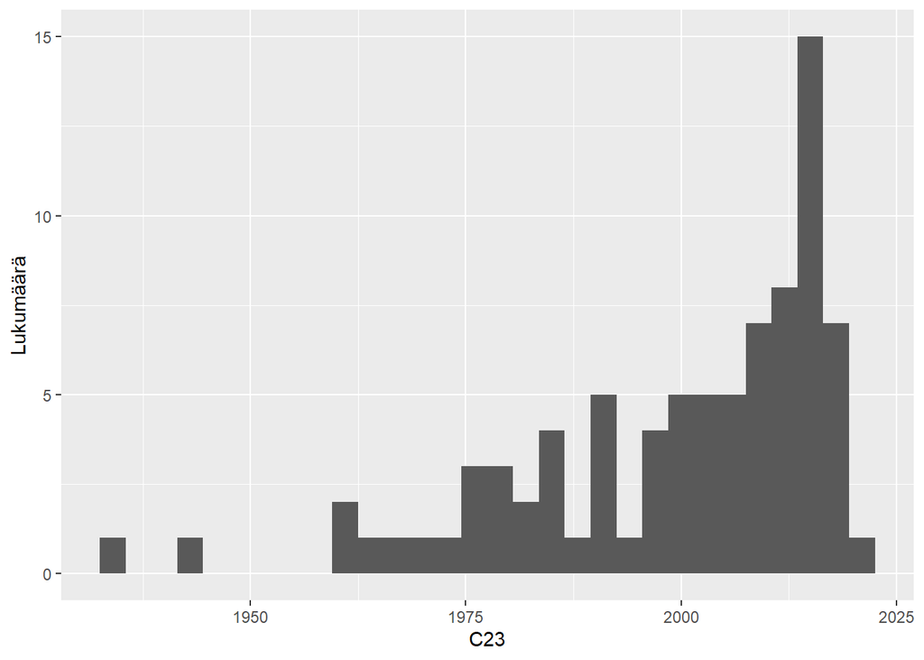

## **C25**: Katsotko kuuluvasti samaan etniseen ryhmään kuin useimmat ihmiset Suomessa?

| Luokka | n | % | % vastanneista |
| --- | --- | --- | --- |
| Kyllä | 1492 | 95.5% | 96.1% |
| Ei | 60 | 3.8% | 3.9% |
| NA | 11 | 0.7% | - |

## **C28**: Onko/oliko äitisi syntynyt Suomessa?

| Luokka | n | % | % vastanneista |
| --- | --- | --- | --- |
| Kyllä | 1493 | 95.5% | 95.6% |
| Ei | 69 | 4.4% | 4.4% |
| NA | 1 | 0.1% | - |

## **C30**: Aiheutuuko ilmastonmuutos mielestäsi luonnonilmiöistä, ihmisen toiminnasta vai molemmista?

| Luokka | n | % | % vastanneista |
| --- | --- | --- | --- |
| Yksinomaan luonnonilmiöistä | 15 | 1.0% | 1.0% |
| Pääosin luonnonilmiöistä | 79 | 5.1% | 5.1% |
| Yhtä paljon luonnonilmiöistä ja ihmisen toiminnasta | 591 | 37.8% | 38.1% |
| Pääosin ihmisen toiminnasta | 714 | 45.7% | 46.0% |
| Yksinomaan ihmisen toiminnasta | 150 | 9.6% | 9.7% |
| Ilmastonmuutosta ei mielestäni ole tapahtumassa | 2 | 0.1% | 0.1% |
| NA | 12 | 0.8% | - |

## **C31**: Missä määrin sinun pitäisi mielestäsi omalta osaltasi yrittää vähentää ilmastonmuutoksen vaikutuksia?

| Luokka | n | % | % vastanneista |
| --- | --- | --- | --- |
| Ei lainkaan | 40 | 2.6% | 2.6% |
| 1 | 28 | 1.8% | 1.8% |
| 2 | 40 | 2.6% | 2.6% |
| 3 | 67 | 4.3% | 4.3% |
| 4 | 62 | 4.0% | 4.0% |
| 5 | 132 | 8.4% | 8.6% |
| 6 | 145 | 9.3% | 9.4% |
| 7 | 300 | 19.2% | 19.4% |
| 8 | 372 | 23.8% | 24.1% |
| 9 | 212 | 13.6% | 13.7% |
| Hyvin paljon | 145 | 9.3% | 9.4% |
| NA | 20 | 1.3% | - |

## **C32**: Kuinka huolestunut olet ilmastonmuutoksesta?

| Luokka | n | % | % vastanneista |
| --- | --- | --- | --- |
| En lainkaan huolestunut | 47 | 3.0% | 3.0% |
| En kovin huolestunut | 234 | 15.0% | 15.0% |
| Jonkin verran huolestunut | 690 | 44.1% | 44.3% |
| Erittäin huolestunut | 490 | 31.3% | 31.5% |
| Äärimmäisen huolestunut | 96 | 6.1% | 6.2% |
| NA | 6 | 0.4% | - |

## **Koeryhmä**: Ilmastonmuutoskysymysten koeryhmä

| Luokka | n | % | % vastanneista |
| --- | --- | --- | --- |
| Ryhmä 1 | 506 | 32.4% | 32.4% |
| Ryhmä 2 | 521 | 33.3% | 33.3% |
| Ryhmä 3 | 536 | 34.3% | 34.3% |

## **C34**: Kuvittele, että suuri joukko ihmisiä rajoittaa energiankulutustaan. Kuinka todennäköistä mielestäsi on, että se hidastaa ilmastonmuutosta?

| Luokka | n | % | % vastanneista |
| --- | --- | --- | --- |
| Ei lainkaan todennäköistä | 5 | 0.3% | 1.0% |
| 1 | 10 | 0.6% | 2.0% |
| 2 | 22 | 1.4% | 4.5% |
| 3 | 27 | 1.7% | 5.5% |
| 4 | 32 | 2.0% | 6.5% |
| 5 | 74 | 4.7% | 15.0% |
| 6 | 81 | 5.2% | 16.4% |
| 7 | 94 | 6.0% | 19.0% |
| 8 | 97 | 6.2% | 19.6% |
| 9 | 22 | 1.4% | 4.5% |
| Äärimmäisen todennäköistä | 30 | 1.9% | 6.1% |
| NA | 1069 | 68.4% | - |

## **C35**: Kuinka todennäköistä mielestäsi on, että suuri joukko ihmisiä todella rajoittaa energiankulutustaan pyrkimyksenään hidastaa ilmastonmuutosta?

| Luokka | n | % | % vastanneista |
| --- | --- | --- | --- |
| Ei lainkaan todennäköistä | 13 | 0.8% | 2.6% |
| 1 | 20 | 1.3% | 4.0% |
| 2 | 61 | 3.9% | 12.3% |
| 3 | 72 | 4.6% | 14.5% |
| 4 | 74 | 4.7% | 14.9% |
| 5 | 78 | 5.0% | 15.7% |
| 6 | 73 | 4.7% | 14.7% |
| 7 | 55 | 3.5% | 11.1% |
| 8 | 43 | 2.8% | 8.7% |
| 9 | 3 | 0.2% | 0.6% |
| Äärimmäisen todennäköistä | 5 | 0.3% | 1.0% |
| NA | 1066 | 68.2% | - |

## **C36**: Kuinka todennäköistä mielestäsi on, että riittävän monen maan hallitukset ryhtyvät toimiin ilmastonmuutoksen vähentämiseksi?

| Luokka | n | % | % vastanneista |
| --- | --- | --- | --- |
| Ei lainkaan todennäköistä | 10 | 0.6% | 2.0% |
| 1 | 17 | 1.1% | 3.4% |
| 2 | 37 | 2.4% | 7.4% |
| 3 | 81 | 5.2% | 16.3% |
| 4 | 77 | 4.9% | 15.5% |
| 5 | 87 | 5.6% | 17.5% |
| 6 | 61 | 3.9% | 12.3% |
| 7 | 72 | 4.6% | 14.5% |
| 8 | 33 | 2.1% | 6.6% |
| 9 | 15 | 1.0% | 3.0% |
| Äärimmäisen todennäköistä | 7 | 0.4% | 1.4% |
| NA | 1066 | 68.2% | - |

## **C37**: Kuvittele, että suuri joukko ihmisiä rajoittaa energiankulutustaan. Kuinka todennäköistä mielestäsi on, että se hidastaa ilmastonmuutosta?

| Luokka | n | % | % vastanneista |
| --- | --- | --- | --- |
| Erittäin todennäköistä | 48 | 3.1% | 9.4% |
| Todennäköistä | 155 | 9.9% | 30.5% |
| Melko todennäköistä | 167 | 10.7% | 32.9% |
| Ei kovin todennäköistä | 123 | 7.9% | 24.2% |
| Ei lainkaan todennäköistä | 15 | 1.0% | 3.0% |
| NA | 1055 | 67.5% | - |

## **C38**: Kuinka todennäköistä mielestäsi on, että suuri joukko ihmisiä todella rajoittaa energiankulutustaan pyrkimyksenään hidastaa ilmastonmuutosta?

| Luokka | n | % | % vastanneista |
| --- | --- | --- | --- |
| Erittäin todennäköistä | 12 | 0.8% | 2.4% |
| Todennäköistä | 58 | 3.7% | 11.4% |
| Melko todennäköistä | 124 | 7.9% | 24.4% |
| Ei kovin todennäköistä | 289 | 18.5% | 56.8% |
| Ei lainkaan todennäköistä | 26 | 1.7% | 5.1% |
| NA | 1054 | 67.4% | - |

## **C39**: Entä kuinka todennäköistä mielestäsi on, että riittävän monen maan hallitukset ryhtyvät toimiin ilmastonmuutoksen vähentämiseksi?

| Luokka | n | % | % vastanneista |
| --- | --- | --- | --- |
| Erittäin todennäköistä | 16 | 1.0% | 3.1% |
| Todennäköistä | 65 | 4.2% | 12.7% |
| Melko todennäköistä | 175 | 11.2% | 34.3% |
| Ei kovin todennäköistä | 232 | 14.8% | 45.5% |
| Ei lainkaan todennäköistä | 22 | 1.4% | 4.3% |
| NA | 1053 | 67.4% | - |

## **C40**: Kuvittele, että suuri joukko ihmisiä rajoittaa energiankulutustaan. Kuinka todennäköistä mielestäsi on, että se hidastaa ilmastonmuutosta?

| Luokka | n | % | % vastanneista |
| --- | --- | --- | --- |
| Ei lainkaan todennäköistä | 30 | 1.9% | 5.7% |
| 1 | 60 | 3.8% | 11.5% |
| 2 | 143 | 9.1% | 27.3% |
| 3 | 175 | 11.2% | 33.4% |
| Erittäin todennäköistä | 116 | 7.4% | 22.1% |
| NA | 1039 | 66.5% | - |

## **C41**: Kuinka todennäköistä mielestäsi on, että suuri joukko ihmisiä todella rajoittaa energiankulutustaan pyrkimyksenään hidastaa ilmastonmuutosta?

| Luokka | n | % | % vastanneista |
| --- | --- | --- | --- |
| Ei lainkaan todennäköistä | 55 | 3.5% | 10.5% |
| 1 | 170 | 10.9% | 32.4% |
| 2 | 201 | 12.9% | 38.3% |
| 3 | 75 | 4.8% | 14.3% |
| Erittäin todennäköistä | 24 | 1.5% | 4.6% |
| NA | 1038 | 66.4% | - |

## **C42**: Entä kuinka todennäköistä mielestäsi on, että riittävän monen maan hallitukset ryhtyvät toimiin ilmastonmuutoksen vähentämiseksi?

| Luokka | n | % | % vastanneista |
| --- | --- | --- | --- |
| Ei lainkaan todennäköistä | 46 | 2.9% | 8.7% |
| 1 | 149 | 9.5% | 28.3% |
| 2 | 211 | 13.5% | 40.1% |
| 3 | 86 | 5.5% | 16.3% |
| Erittäin todennäköistä | 34 | 2.2% | 6.5% |
| NA | 1037 | 66.3% | - |

## **C43**: Äänestäisitkö sen puolesta, että Suomi pysyy Euroopan unionin jäsenenä vai sen puolesta, että Suomi eroaa Euroopan unionista?

| Luokka | n | % | % vastanneista |
| --- | --- | --- | --- |
| Pysyy Euroopan unionissa | 1339 | 85.7% | 86.9% |
| Eroaa Euroopan unionista | 148 | 9.5% | 9.6% |
| Jättäisin tyhjän äänestyslipun | 10 | 0.6% | 0.6% |
| Jättäisin sotketun äänestyslipun | 2 | 0.1% | 0.1% |
| En äänestäisi | 31 | 2.0% | 2.0% |
| En ole äänioikeutettu | 10 | 0.6% | 0.6% |
| NA | 23 | 1.5% | - |

# D: Ruoka, alkoholi, terveysongelmat

## **D1**: Missä määrin tunnet itse nykyisin hallitsevasi elämääsi yleisesti?

| Luokka | n | % | % vastanneista |
| --- | --- | --- | --- |
| En hallitse lainkaan | 1 | 0.1% | 0.1% |
| 2 | 5 | 0.3% | 0.3% |
| 3 | 15 | 1.0% | 1.0% |
| 4 | 26 | 1.7% | 1.7% |
| 5 | 33 | 2.1% | 2.1% |
| 6 | 62 | 4.0% | 4.0% |
| 7 | 193 | 12.3% | 12.4% |
| 8 | 490 | 31.3% | 31.4% |
| 9 | 512 | 32.8% | 32.8% |
| Hallitsen täysin | 222 | 14.2% | 14.2% |
| NA | 4 | 0.3% | - |

## **D2**: Kuinka usein syöt hedelmiä ja marjoja, jos mehuja ei lasketa?

| Luokka | n | % | % vastanneista |
| --- | --- | --- | --- |
| Vähintään kolme kertaa päivässä | 95 | 6.1% | 6.1% |
| Kahdesti päivässä | 362 | 23.2% | 23.2% |
| Kerran päivässä | 598 | 38.3% | 38.3% |
| Harvemmin kuin kerran päivässä, mutta vähintään neljä kertaa viikossa | 275 | 17.6% | 17.6% |
| Harvemmin kuin neljä kertaa viikossa, mutta vähintään kerran viikossa | 157 | 10.0% | 10.0% |
| Harvemmin kuin kerran viikossa | 75 | 4.8% | 4.8% |
| En koskaan | 1 | 0.1% | 0.1% |

## **D3**: Kuinka usein syöt juureksia, vihanneksia tai salaattia, jos perunoita ei lasketa?

| Luokka | n | % | % vastanneista |
| --- | --- | --- | --- |
| Vähintään kolme kertaa päivässä | 93 | 6.0% | 6.0% |
| Kahdesti päivässä | 365 | 23.4% | 23.4% |
| Kerran päivässä | 688 | 44.0% | 44.0% |
| Harvemmin kuin kerran päivässä, mutta vähintään neljä kertaa viikossa | 269 | 17.2% | 17.2% |
| Harvemmin kuin neljä kertaa viikossa, mutta vähintään kerran viikossa | 105 | 6.7% | 6.7% |
| Harvemmin kuin kerran viikossa | 39 | 2.5% | 2.5% |
| En koskaan | 4 | 0.3% | 0.3% |

## **D4**: Kuinka monena päivänä seitsemän viime päivän aikana kävelit reippaasti, urheilit tai harrastit muuta liikuntaa vähintään 30 minuutin ajan?

| Tieto | Arvo |
| --- | --- |
| Vastanneita | 1559.00 |
| Keskiarvo | 4.05 |
| Keskihajonta | 2.34 |
| Minimi | 0.00 |
| Maksimi | 7.00 |

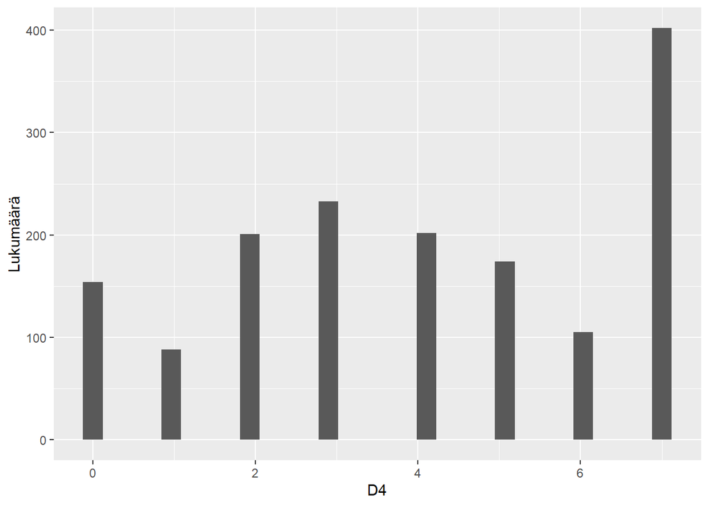

## **D5**: Mikä vaihtoehdoista kuvaa parhaiten tupakointiasi?

| Luokka | n | % | % vastanneista |
| --- | --- | --- | --- |
| Tupakoin päivittäin, yleensä vähintään 10 savuketta | 95 | 6.1% | 6.1% |
| Tupakoin päivittäin, yleensä enintään 9 savuketta | 63 | 4.0% | 4.0% |
| Tupakoin, mutten päivittäin | 72 | 4.6% | 4.6% |
| En tupakoi, mutta olen tupakoinut aiemmin | 473 | 30.3% | 30.3% |
| Olen tupakoinut vain muutamia kertoja | 292 | 18.7% | 18.7% |
| En ole koskaan tupakoinut | 567 | 36.3% | 36.3% |
| NA | 1 | 0.1% | - |

## **D6**: Kuinka usein olet nauttinut alkoholijuomia kahdentoista viime kuukauden aikana?

| Luokka | n | % | % vastanneista |
| --- | --- | --- | --- |
| Päivittäin | 23 | 1.5% | 1.5% |
| Useita kertoja viikossa | 159 | 10.2% | 10.2% |
| Kerran viikossa | 299 | 19.1% | 19.2% |
| 2-3 kertaa kuukaudessa | 266 | 17.0% | 17.1% |
| Kerran kuukaudessa | 198 | 12.7% | 12.7% |
| Harvemmin kuin kerran kuukaudessa | 363 | 23.2% | 23.3% |
| En koskaan | 252 | 16.1% | 16.2% |
| NA | 3 | 0.2% | - |

## **D7**: Kuinka monta grammaa alkoholia nautti viimeksi juodessaan arkipäivänä (ma-to)

| Tieto | Arvo |
| --- | --- |
| Vastanneita | 1304.00 |
| Keskiarvo | 23.14 |
| Keskihajonta | 38.94 |
| Minimi | 0.00 |
| Maksimi | 448.00 |

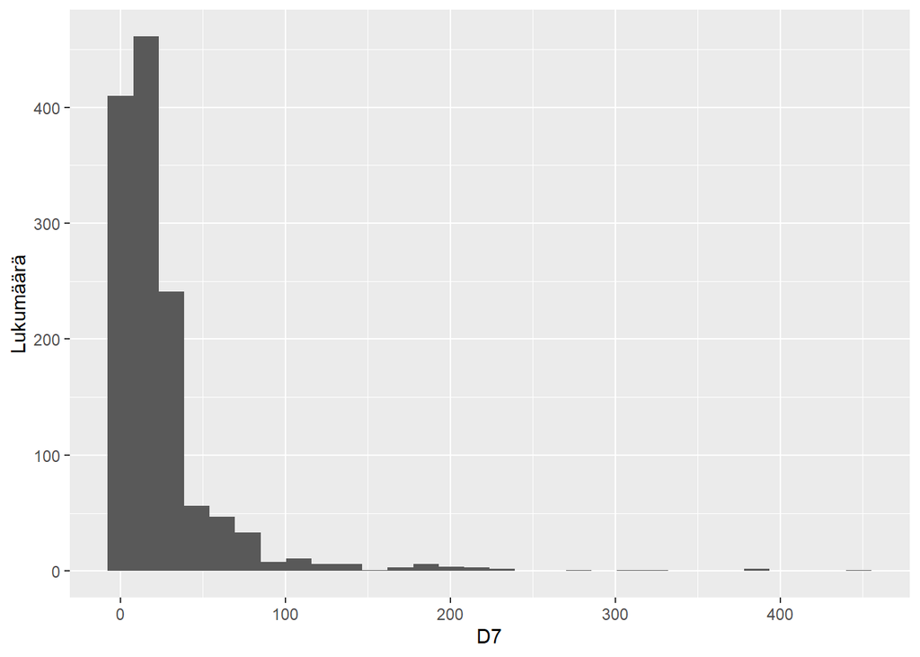

## **D8**: Kuinka monta grammaa alkoholia nautti viimeksi juodessaan viikonloppuna (pe-su)

| Tieto | Arvo |
| --- | --- |
| Vastanneita | 1305.00 |
| Keskiarvo | 53.06 |
| Keskihajonta | 84.59 |
| Minimi | 0.00 |
| Maksimi | 2244.00 |

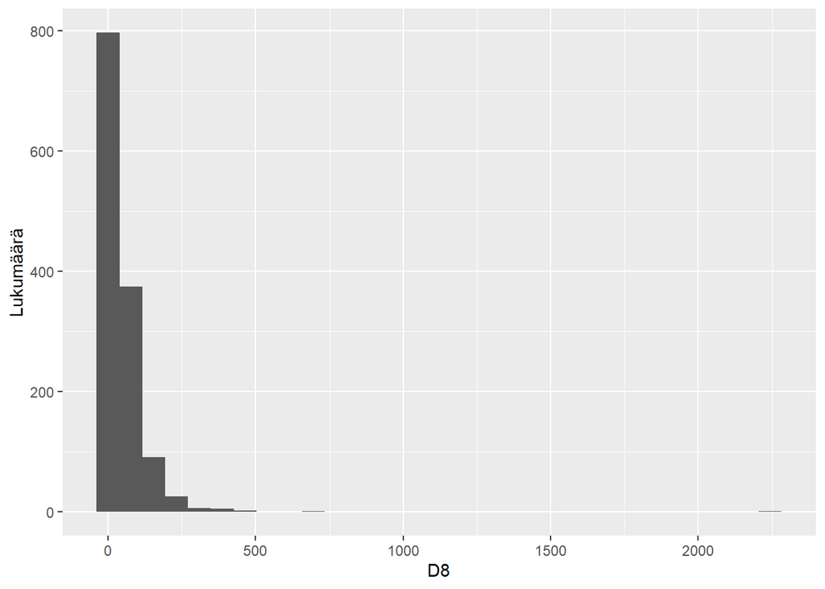

## **D10**: Humalahakuinen juominen, kertoja viimeisen 12kk aikana

| Luokka | n | % | % vastanneista |
| --- | --- | --- | --- |
| Päivittäin tai melkein päivittäin | 14 | 0.9% | 1.1% |
| Viikoittain | 144 | 9.2% | 10.9% |
| Kuukausittain | 258 | 16.5% | 19.5% |
| Harvemmin kuin kuukausittain | 520 | 33.3% | 39.2% |
| Ei koskaan | 390 | 25.0% | 29.4% |
| NA | 237 | 15.2% | - |

## **D11_cm**: Kuinka pitkä olet ilman kenkiä (cm)?

| Tieto | Arvo |
| --- | --- |
| Vastanneita | 1530.00 |
| Keskiarvo | 171.69 |
| Keskihajonta | 9.30 |
| Minimi | 148.00 |
| Maksimi | 201.00 |

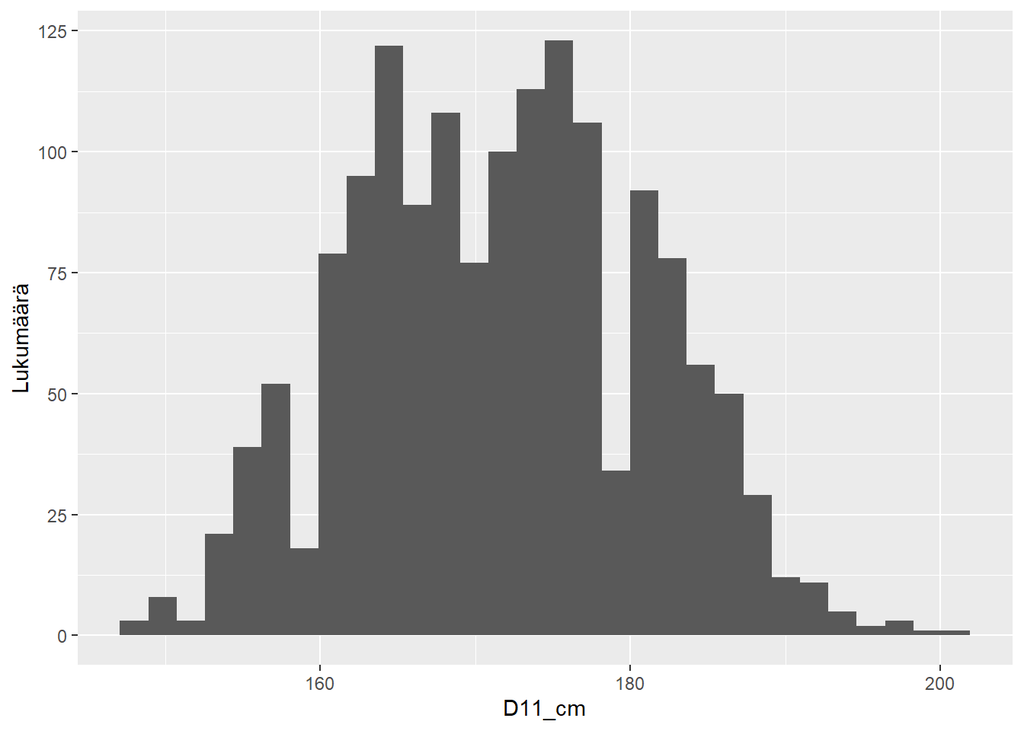

## **D12**: Kuinka paljon painat ilman kenkiä (kg)?

| Tieto | Arvo |
| --- | --- |
| Vastanneita | 1499.00 |
| Keskiarvo | 78.47 |
| Keskihajonta | 16.25 |
| Minimi | 43.00 |
| Maksimi | 140.00 |

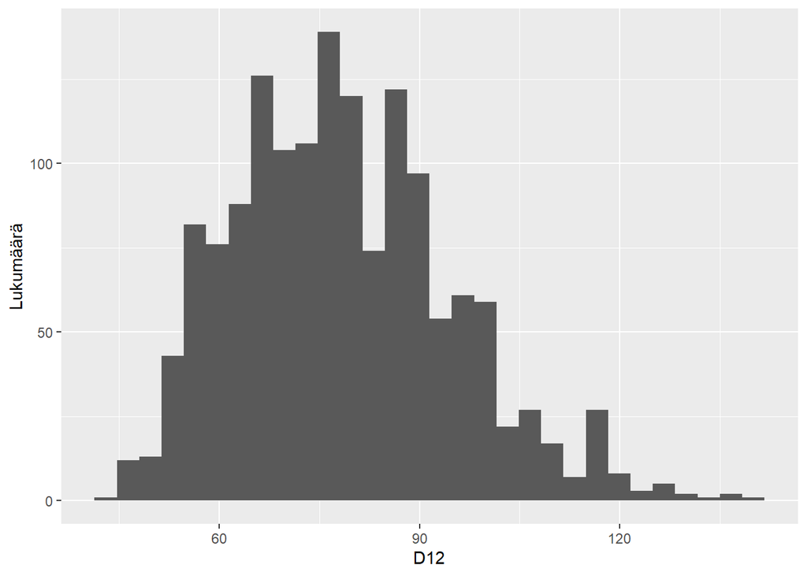